# Crypto Stock Analysis

This project examines relationships between cryptocurrencies and traditional equity markets using volatility analysis, rolling statistics, correlation analysis, Granger causality testing, and Vector Autoregression (VAR) modeling.

The analysis compares major cryptocurrencies with broad market indices and sector based equity groups to evaluate market integration, volatility behavior, and predictive relationships over time.

```python
import pandas as pd
import numpy as np
import matplotlib.pyplot as plt
import seaborn as sns
import math
import matplotlib.dates as mdates
import matplotlib.cm as cm
import warnings

from functools import reduce
from statsmodels.tsa.stattools import adfuller
from statsmodels.tsa.api import VAR
from statsmodels.stats.stattools import durbin_watson
from statsmodels.tsa.stattools import grangercausalitytests
from arch import arch_model

import glob
import os

import yfinance as yf
from datetime import datetime
```

## Data Loading

### Dataset Overview

This analysis combines cryptocurrency prices, major stock indices, and specific sector equity data to examine volatility, predictive relationships, and market integration between digital assets and traditional financial markets.

```python
# Stocks
sp500 = pd.read_csv("data/Stocks/SP500.csv")
dow = pd.read_csv("data/Stocks/DJIA.csv")
nas_com = pd.read_csv("data/Stocks/NASDAQCOM.csv")
nas_100 = pd.read_csv("data/Stocks/NASDAQ100.csv")

# Crypto
btc = pd.read_csv("data/Crypto/CBBTCUSD.csv")
eth = pd.read_csv("data/Crypto/CBETHUSD.csv")
bch = pd.read_csv("data/Crypto/CBBCHUSD.csv")
ltc = pd.read_csv("data/Crypto/CBLTCUSD.csv")
```

```python
# Sector folder paths
tech_path = "data/Sectors/Technology"
fin_path = "data/Sectors/Financial"
cons_path = "data/Sectors/Consumer"
comm_path = "data/Sectors/Communication"
hlth_path = "data/Sectors/Healthcare"
energy_path = "data/Sectors/Energy"

# Load and merge all csvs in a folder on observation_date
def load_sector_folder(folder_path):
    csv_files = glob.glob(os.path.join(folder_path, "*.csv"))
    csv_files = sorted(csv_files)

    df_list = [pd.read_csv(file, usecols=[0, 1]) for file in csv_files]

    sector_df = df_list[0]
    for df in df_list[1:]:
        sector_df = pd.merge(sector_df, df, on="observation_date", how="left")

    return sector_df

# Load sector data
tech_df = load_sector_folder(tech_path)
fin_df = load_sector_folder(fin_path)
cons_df = load_sector_folder(cons_path)
comm_df = load_sector_folder(comm_path)
hlth_df = load_sector_folder(hlth_path)
energy_df = load_sector_folder(energy_path)

# Check shapes
print("Technology:", tech_df.shape)
print("Financial:", fin_df.shape)
print("Consumer:", cons_df.shape)
print("Communication:", comm_df.shape)
print("Healthcare:", hlth_df.shape)
print("Energy:", energy_df.shape)
```

```
Technology: (2515, 6)
Financial: (2515, 6)
Consumer: (2515, 6)
Communication: (2515, 6)
Healthcare: (2515, 6)
Energy: (2515, 6)
```

```python
# Convert observation_date columns to datetime
date_dfs = [
    sp500, dow, nas_com, nas_100,
    btc, eth, bch, ltc,
    tech_df, fin_df, cons_df, comm_df, hlth_df, energy_df
]

for df in date_dfs:
    df["observation_date"] = pd.to_datetime(df["observation_date"])

# Rename crypto price columns
btc = btc.rename(columns={"CBBTCUSD": "Bitcoin"})
eth = eth.rename(columns={"CBETHUSD": "Ethereum"})
bch = bch.rename(columns={"CBBCHUSD": "BitcoinCash"})
ltc = ltc.rename(columns={"CBLTCUSD": "Litecoin"})
```

```python
raw_dfs_list = [
    sp500,
    dow,
    nas_com,
    nas_100,
    btc,
    eth,
    bch,
    ltc,
    tech_df,
    fin_df,
    cons_df,
    comm_df,
    hlth_df,
    energy_df
]

combined_df = reduce(
    lambda left, right: pd.merge(left, right, on="observation_date", how="inner"),
    raw_dfs_list
)

combined_df = combined_df.sort_values("observation_date").reset_index(drop=True)

print(combined_df.shape)
combined_df[['observation_date','SP500','Bitcoin']].head()
```

```
(1946, 39)
```

|  | observation_date | SP500 | Bitcoin |
| --- | --- | --- | --- |
| 0 | 2017-12-20 | 2679.25 | 16496.89 |
| 1 | 2017-12-21 | 2684.57 | 15758.80 |
| 2 | 2017-12-22 | 2683.34 | 14210.57 |
| 3 | 2017-12-26 | 2680.50 | 15790.88 |
| 4 | 2017-12-27 | 2682.62 | 15367.08 |

```python
def make_avg_df(df, sector_name):
    # sort by observation_date for chronological order
    df = df.sort_values("observation_date").reset_index(drop=True)

    # stock columns
    stock_cols = [col for col in df.columns if col != "observation_date"]

    # percent change for each stock
    pct_change = df[stock_cols].pct_change(fill_method=None)

    # row-wise average
    avg_pct = pct_change.mean(axis=1)

    # new dataframe w date & average
    return pd.DataFrame({
        "observation_date": df["observation_date"],
        f"{sector_name}_avg_pct_change": avg_pct
    })

# sector average dataframes
tech_avg_df = make_avg_df(tech_df, "tech")
fin_avg_df = make_avg_df(fin_df, "fin")
cons_avg_df = make_avg_df(cons_df, "cons")
comm_avg_df = make_avg_df(comm_df, "comm")
hlth_avg_df = make_avg_df(hlth_df, "hlth")
energy_avg_df = make_avg_df(energy_df, "energy")

# percent change for all numeric columns in the aligned combined dataset
numeric_combined_df = df.select_dtypes(include=[np.number])
combined_avg_df = numeric_combined_df.pct_change(fill_method=None)
combined_avg_df.insert(0, "observation_date", combined_df["observation_date"])

# merge in sector average returns
sectors = [
    tech_avg_df,
    fin_avg_df,
    cons_avg_df,
    comm_avg_df,
    hlth_avg_df,
    energy_avg_df
]

# rename sector average columns
combined_avg_df.rename(columns={
    "tech_avg_pct_change": "Tech Avg",
    "fin_avg_pct_change": "Fin Avg",
    "cons_avg_pct_change": "Cons Avg",
    "comm_avg_pct_change": "Comm Avg",
    "hlth_avg_pct_change": "Hlth Avg",
    "energy_avg_pct_change": "Energy Avg"
}, inplace=True)

print(combined_avg_df.shape)
print(combined_avg_df.isna().sum().sort_values(ascending=False).head(10))

combined_avg_df = combined_avg_df.dropna()
```

```
(2515, 6)
observation_date    569
COP                   1
CVX                   1
EPD                   1
WMB                   1
XOM                   1
dtype: int64
```

```python
# Final dataset cleaning
df = combined_avg_df.copy()

df = df.rename(columns={
    'CBBTCUSD': 'Bitcoin',
    'CBETHUSD': 'Ethereum',
    'CBBCHUSD': 'BitcoinCash',
    'CBLTCUSD': 'Litecoin',
    'DJIA': 'Dow',
    'NASDAQCOM': 'Nas Com',
    'NASDAQ100': 'Nas 100'
})

print(df.shape)
```

```
(1945, 6)
```

### Data Cleaning

```python
# Create separate copies of the cleaned dataset for different analyses
corr_df = combined_avg_df.copy()
vol_df = combined_avg_df.copy()
ts_df = combined_avg_df.copy()
```

## Volatility Analysis

```python
# Select only numeric columns from cleaned dataset
numeric_df = combined_avg_df.select_dtypes(include="number")

# Summary statistics
summary_stats = pd.DataFrame({
    "Min": numeric_df.min(),
    "Max": numeric_df.max(),
    "Median": numeric_df.median(),
    "Range": numeric_df.max() - numeric_df.min(),
    "Mean": numeric_df.mean(),
    "Std Dev": numeric_df.std()
})

pd.set_option('display.float_format', lambda x: '%.2f' % x)

print("Summary Statistics for Each Market:")
print(summary_stats)
```

```
Summary Statistics for Each Market:
      Min  Max  Median  Range  Mean  Std Dev
COP -0.20 0.33   -0.00   0.53  0.00     0.03
CVX -0.19 0.28   -0.00   0.47  0.00     0.02
EPD -0.15 0.23   -0.00   0.38  0.00     0.02
WMB -0.16 0.31   -0.00   0.47 -0.00     0.02
XOM -0.11 0.14   -0.00   0.25  0.00     0.02
```

### Candlestick-Style Return Charts

The following charts show monthly return movement and highlight the most volatile months for each selected market.

```python
#Building candlestick analysis plots
def candlestick_analysis(data, candles):
    df_plot = data[["observation_date", candles]].copy()
    df_plot = df_plot.dropna(subset=[candles])
    df_plot["observation_date"] = pd.to_datetime(df_plot["observation_date"])
    df_plot = df_plot.sort_values("observation_date")
    df_plot = df_plot.set_index("observation_date")

    returns = df_plot[candles].pct_change(fill_method=None)
    # clean bad values
    returns = returns.replace([np.inf, -np.inf], np.nan).dropna()

    monthly_summary = returns.resample("ME").agg(
        Start="first",
        Max="max",
        Min="min",
        End="last"
    ).dropna()

    monthly_summary["Volatility"] = monthly_summary["Max"] - monthly_summary["Min"]

    # Monthly candlestick chart
    fig, ax = plt.subplots(figsize=(10, 5))
    x = range(len(monthly_summary))

    for i, (month_high, month_low) in enumerate(zip(monthly_summary["Max"], monthly_summary["Min"])):
        ax.vlines(x=i, ymin=month_low, ymax=month_high, linewidth=1)

    for i, (start, end) in enumerate(zip(monthly_summary["Start"], monthly_summary["End"])):
        lower = min(start, end)
        height = abs(end - start)
        color = "tab:green" if end >= start else "tab:red"
        ax.add_patch(plt.Rectangle((i - 0.4, lower), 0.8, height,
                                   edgecolor="black", facecolor=color, linewidth=0.85))

    ax.set_title(f"{candles} Monthly Returns Movement")
    ax.set_xlabel("Month")
    ax.set_ylabel("Return")
    ax.grid(axis="y", linestyle="--", alpha=0.3)

    step = 6
    tick_idx = list(range(0, len(monthly_summary), step))
    ax.set_xticks(tick_idx)
    ax.set_xticklabels([monthly_summary.index[i].strftime("%Y-%m") for i in tick_idx],
                       rotation=30, ha="right")

    plt.tight_layout()
    plt.show()

    top_6 = monthly_summary.sort_values(by="Volatility", ascending=False).head(6)

    print(f"Top 6 Most Volatile Months: {candles}")
    print(top_6[["Start", "End", "Max", "Min", "Volatility"]])

    # Weekly breakdown chart
    fig, axes = plt.subplots(2, 3, figsize=(15, 8), sharey=True)
    axes = axes.flatten()
    fig.suptitle(f"{candles} Weekly Breakdown of Top 6 Volatile Months")

    for idx, (month, row) in enumerate(top_6.iterrows()):
        month_returns = returns.loc[month.strftime("%Y-%m")]

        weekly_summary = month_returns.resample("W").agg(
            Start="first",
            Max="max",
            Min="min",
            End="last"
        ).dropna()

        ax = axes[idx]
        x = range(len(weekly_summary))

        for i, (week_high, week_low) in enumerate(zip(weekly_summary["Max"], weekly_summary["Min"])):
            ax.vlines(x=i, ymin=week_low, ymax=week_high, linewidth=1)

        for i, (start, end) in enumerate(zip(weekly_summary["Start"], weekly_summary["End"])):
            lower = min(start, end)
            height = abs(end - start)
            color = "tab:green" if end >= start else "tab:red"
            ax.add_patch(plt.Rectangle((i - 0.4, lower), 0.8, height,
                                       edgecolor="black", facecolor=color, linewidth=0.85))

        ax.set_title(month.strftime("%Y-%m"))
        ax.set_xticks(range(len(weekly_summary)))
        ax.set_xticklabels([weekly_summary.index[i].strftime("%d") for i in range(len(weekly_summary))],
                           rotation=30, ha="right")
        ax.grid(axis="y", linestyle="--", alpha=0.3)

    plt.tight_layout()
    plt.show()
```

### Bitcoin Returns - Cryptocurrency

Bitcoin is examined first as the leading cryptocurrency asset. The chart below shows monthly return movement and identifies periods with larger swings in returns.

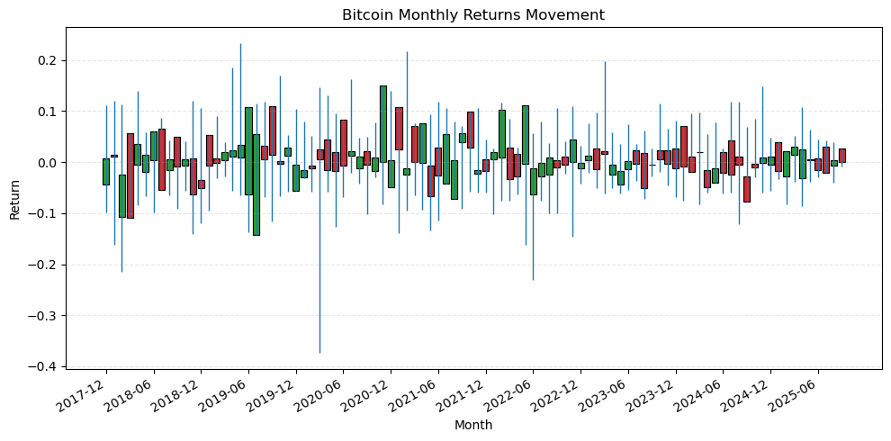

```
Top 6 Most Volatile Months: Bitcoin
                  Start   End  Max   Min  Volatility
observation_date
2020-03-31         0.02  0.01 0.15 -0.37        0.52
2018-02-28        -0.11 -0.02 0.11 -0.21        0.33
2021-02-28        -0.03 -0.01 0.22 -0.10        0.31
2019-05-31         0.01  0.03 0.23 -0.07        0.30
2022-06-30        -0.06 -0.01 0.06 -0.23        0.29
2018-01-31         0.01  0.01 0.12 -0.16        0.28
```

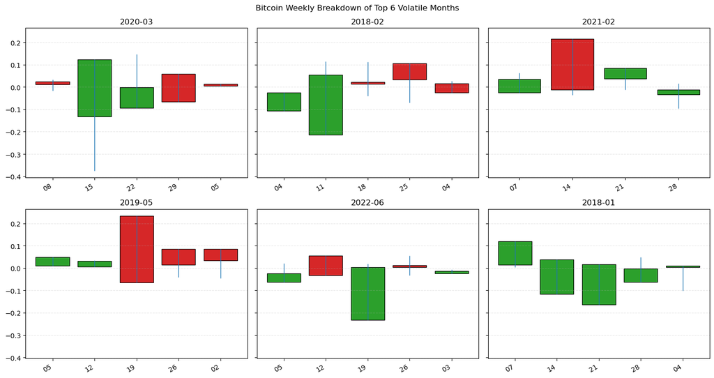

```python
candlestick_analysis(combined_df, "Bitcoin")
```

### S&P 500 - General Market

The S&P 500 represents broad U.S. market performance and provides a benchmark for comparing cryptocurrency volatility against traditional equities.

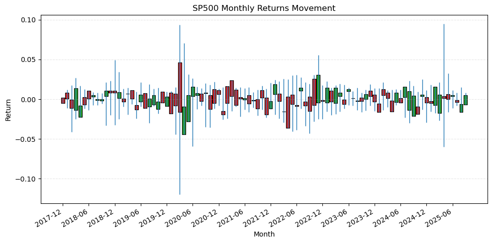

```
Top 6 Most Volatile Months: SP500
                  Start   End  Max   Min  Volatility
observation_date
2020-03-31         0.05 -0.02 0.09 -0.12        0.21
2025-04-30         0.00  0.00 0.10 -0.06        0.15
2020-04-30        -0.04 -0.01 0.07 -0.04        0.11
2020-06-30         0.00  0.02 0.03 -0.06        0.09
2018-12-31         0.01  0.01 0.05 -0.03        0.08
2022-11-30        -0.00  0.03 0.06 -0.03        0.08
```

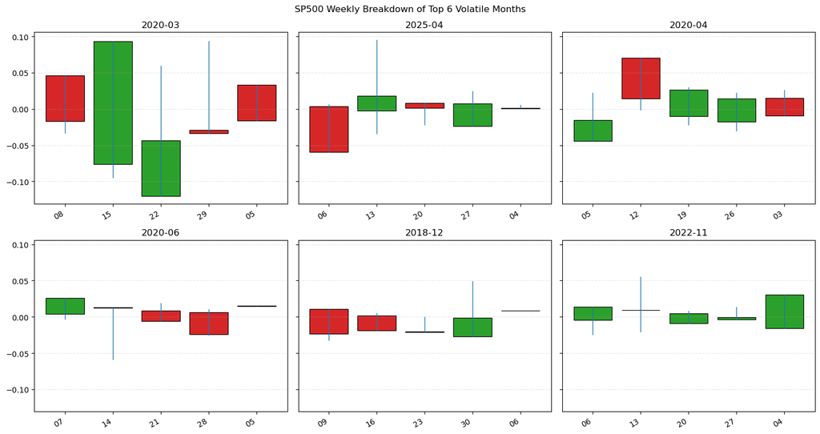

```python
candlestick_analysis(combined_df, "SP500")
```

### NASDAQ 100 - Technology

The NASDAQ 100 emphasizes large technology-focused companies and is used to compare volatility patterns between growth-oriented equities and cryptocurrencies.

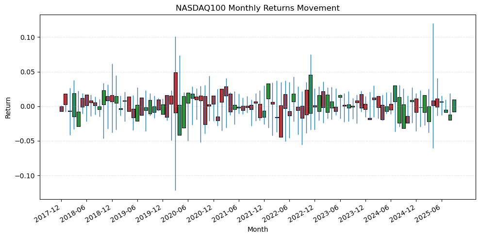

```
Top 6 Most Volatile Months: NASDAQ100
                  Start   End  Max   Min  Volatility
observation_date
2020-03-31         0.05 -0.01 0.10 -0.12        0.22
2025-04-30         0.01  0.00 0.12 -0.06        0.18
2020-04-30        -0.04  0.00 0.07 -0.04        0.12
2022-11-30        -0.01  0.05 0.07 -0.03        0.11
2018-12-31         0.02  0.01 0.06 -0.04        0.10
2022-05-31         0.02 -0.00 0.04 -0.05        0.09
```

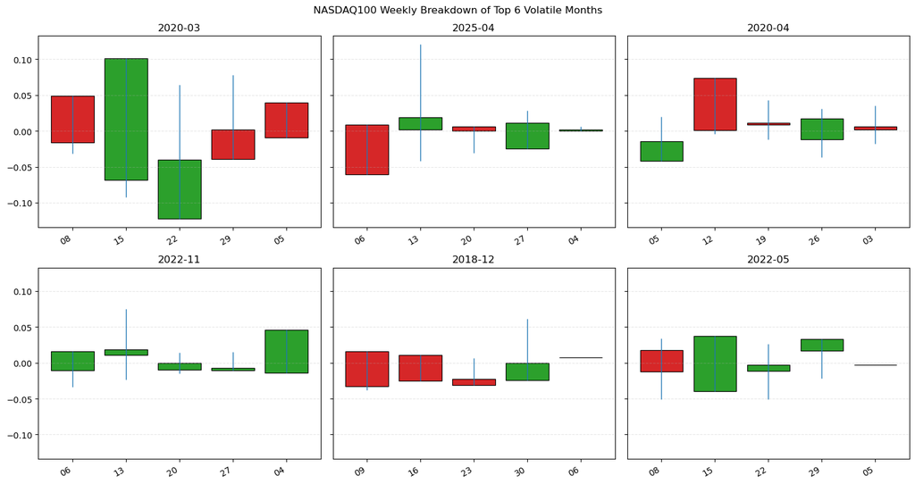

```python
candlestick_analysis(combined_df, "NASDAQ100")
```

### Energy Sector

The energy sector is included to compare volatility patterns in industry specific equities against broader stock and cryptocurrency markets.

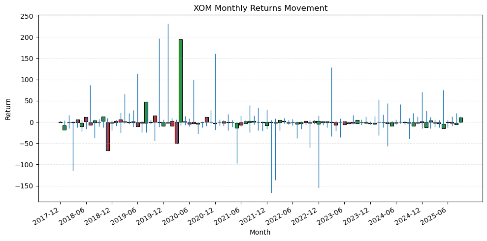

```
Top 6 Most Volatile Months: XOM
                  Start    End    Max     Min  Volatility
observation_date
2020-01-31        -2.13  -0.67 232.02   -2.74      234.76
2019-11-30         0.13  -0.89 196.96  -12.00      208.96
2020-04-30        -0.18 193.98 193.98   -7.98      201.96
2020-12-31        -3.83  -2.06 160.98  -18.30      179.28
2022-01-31        -0.35  -1.69   4.78 -167.03      171.81
2022-12-31        -4.19   2.89  15.25 -154.96      170.21
```

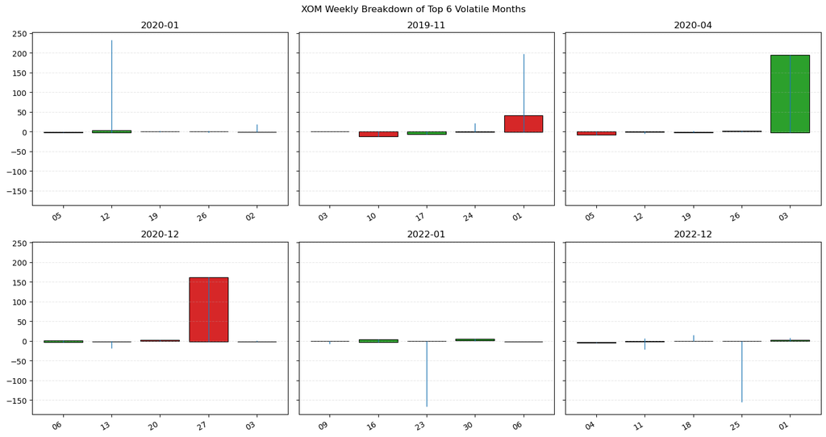

```python
candlestick_analysis(combined_avg_df, "XOM")
```

### Most Volatile Months

The first table in each section identifies the six months with the largest return ranges for the selected asset. These periods represent higher levels of market volatility and larger price movement within a single month.

### Weekly Volatility Breakdown

The charts below each table represent a breakdown of the most volatile months into weekly return movements. This provides a closer view of how volatility developed within each month and highlights periods of concentrated market movement.

## Price Trends Over Time

This section compares closing values for stock market indices and cryptocurrencies over the shared analysis period.

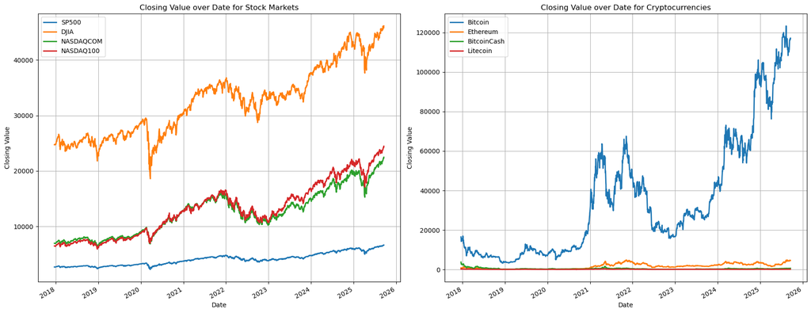

```python
# Set the 'observation_date' column as the index for plotting for main markets
market_cols = ["Bitcoin", "Ethereum", "BitcoinCash", "Litecoin", "SP500", "DJIA", "NASDAQCOM", "NASDAQ100"]

#Split into stocks and crypto for visibility
stock_cols = ["SP500", "DJIA", "NASDAQCOM", "NASDAQ100"]
crypto_cols = ["Bitcoin", "Ethereum", "BitcoinCash", "Litecoin"]

df_plot = combined_df[["observation_date"] + market_cols].copy()
df_plot = df_plot.sort_values("observation_date")
df_plot = df_plot.set_index("observation_date")

fig, axes = plt.subplots(1, 2, figsize=(18, 7))

df_plot[stock_cols].plot(ax=axes[0], linewidth=2)
axes[0].set_title("Closing Value over Date for Stock Markets")
axes[0].set_xlabel("Date")
axes[0].set_ylabel("Closing Value")
axes[0].grid(True)

df_plot[crypto_cols].plot(ax=axes[1], linewidth=2)
axes[1].set_title("Closing Value over Date for Cryptocurrencies")
axes[1].set_xlabel("Date")
axes[1].set_ylabel("Closing Value")
axes[1].grid(True)

plt.tight_layout()
plt.show()
```

## Market Summary Statistics

```python
# Select key market columns
market_cols = ["Bitcoin", "Ethereum", "BitcoinCash", "Litecoin", "SP500", "DJIA", "NASDAQCOM", "NASDAQ100"]

numeric_df = combined_df[market_cols]

#Summary table with key values
summary_stats = pd.DataFrame({'Min': numeric_df.min(), 'Max': numeric_df.max(), 'Median': numeric_df.median(),
                              'Range': numeric_df.max() - numeric_df.min(), 'Mean':numeric_df.mean(), 'Standard Deviation': numeric_df.std()})
pd.set_option('display.float_format', lambda x: '%.2f' % x) #format to 2 decimal places

# print table showing all key data
print("Minimum, Maximum, Median, Range, Mean, and Standard Deviation for Each Market: ")
print(summary_stats)
```

```
Minimum, Maximum, Median, Range, Mean, and Standard Deviation for Each Market:
                 Min       Max   Median     Range     Mean  Standard Deviation
Bitcoin      3195.71 123365.63 26341.33 120169.92 34830.89            30228.11
Ethereum       83.00   4831.24  1629.92   4748.24  1635.92             1269.92
BitcoinCash    79.40   3746.84   321.29   3667.44   407.72              342.36
Litecoin       22.84    377.79    80.75    354.95    95.10               51.68
SP500        2237.40   6631.96  3998.89   4394.56  4043.18             1079.16
DJIA        18591.93  46142.42 32979.38  27550.49 32437.29             6170.66
NASDAQCOM    6192.92  22470.73 12275.58  16277.81 12455.81             3994.16
NASDAQ100    5899.35  24454.89 12800.63  18555.54 13034.37             4792.82
```

This table summarizes the minimum, maximum, median, range, mean, and standard deviation for the selected markets. These statistics provide a numerical comparison of market scale and variability before moving into correlation and volatility analysis.

## Correlation Analysis

This section examines the relationships between cryptocurrency returns and traditional market sectors using correlation analysis. Stronger correlations indicate assets that tend to move more closely together over time.

```python
# Daily Returns Dataset
start = datetime(2015, 9, 21)
end = datetime(2025, 9, 19)

assets = {
    "SPY": "SP500",
    "XLK": "Technology",
    "XLF": "Financials",
    "XLU": "Utilities",
    "BTC-USD": "Bitcoin",
    "ETH-USD": "Ethereum",
    "BCH-USD": "BitcoinCash",
    "LTC-USD": "Litecoin"
}

returns = {}

for ticker, label in assets.items():
    data = yf.download(ticker, start = start, end = end, progress = False)

    close = data["Close"]
    if isinstance(close, pd.DataFrame):
        close = close.iloc[:, 0]

    returns[label] = 100 * close.pct_change()

returns_df = pd.DataFrame(returns).dropna()
```

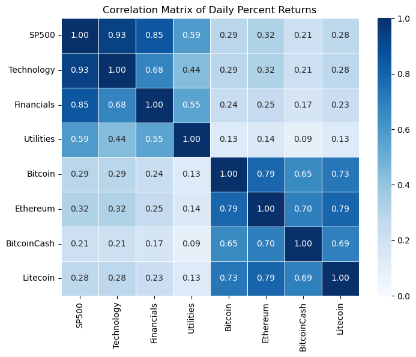

```python
# correlation heatmap
corr = returns_df.corr()

plt.figure(figsize = (8,6))
sns.heatmap(corr, annot = True, cmap = "Blues", vmin = 0, vmax = 1, fmt = ".2f", linewidths = 0.5)
plt.title("Correlation Matrix of Daily Percent Returns")
plt.show()
```

The correlation matrix shows stronger relationships within traditional equity sectors and within cryptocurrencies, while correlations between stocks and cryptocurrencies remain comparatively weaker. This suggests that digital assets maintain partial independence from traditional equity markets.

### Rolling Volatility Comparison

```python
vol_stock_cols = ["SP500", "Technology", "Financials", "Utilities"]
vol_crypto_cols = ["Bitcoin", "Ethereum", "BitcoinCash", "Litecoin"]


window = 60 # rolling volatility over 3 months (trading days, approx)
```

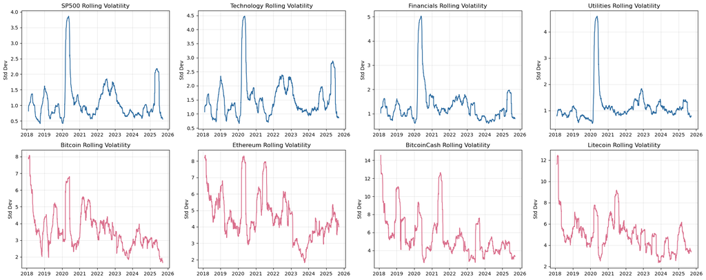

```python
plt.style.use('default')
fig, axes = plt.subplots(2, 4, figsize=(20,8), sharey=False)

# Plot rolling volatility for stocks
for i, stock in enumerate(vol_stock_cols):
    rolling_vol = returns_df[stock].dropna().rolling(window).std()
    axes[0, i].plot(rolling_vol, color='#2C6BA0')
    axes[0, i].set_title(f"{stock} Rolling Volatility", fontsize=12)
    axes[0, i].set_ylabel('Std Dev')
    axes[0, i].grid(alpha=0.3)

# Plot rolling volatility for cryptos
for i, crypto in enumerate(vol_crypto_cols):
    rolling_vol = returns_df[crypto].dropna().rolling(window).std()
    axes[1, i].plot(rolling_vol, color='#D96C8A')
    axes[1, i].set_title(f"{crypto} Rolling Volatility", fontsize=12)
    axes[1, i].set_ylabel('Std Dev')
    axes[1, i].grid(alpha=0.3)

plt.tight_layout()
plt.show()
```

The rolling volatility charts show that cryptocurrencies generally experience larger and more frequent volatility spikes than traditional equity sectors. Stock sector volatility remains more stable overall, while cryptocurrency volatility shows sharper swings across the analysis period.

### Granger Causality Analysis

Granger causality tests are used to examine whether past returns from one market help explain returns in another. Lower p values suggest stronger evidence of a predictive relationship.

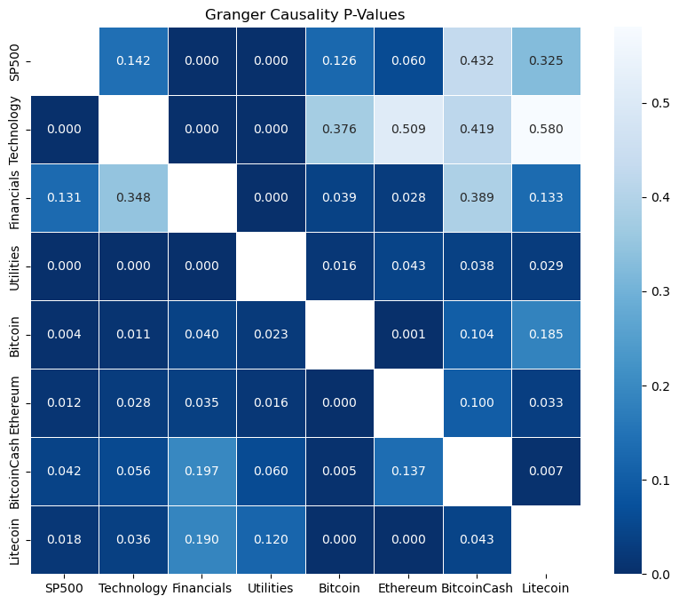

```python
warnings.filterwarnings("ignore") # for verbose depreciation warnings
variables = returns_df.columns
p_values = pd.DataFrame(index=variables, columns=variables)

for row in variables:
    for col in variables:

        if row == col:
            p_values.loc[row, col] = np.nan

        else:
            test_result = grangercausalitytests(
                returns_df[[ row, col]].dropna(),
                maxlag = 5,
                verbose = False
            )

            pvals = [test_result[i + 1][0]['ssr_ftest'][1] for i in range(5)]
            p_values.loc[row, col] = min(pvals)

p_values = p_values.astype(float)

plt.figure(figsize=(10,8))

sns.heatmap(p_values, annot = True, fmt = ".3f", cmap = "Blues_r", linewidths = 0.5)

plt.title("Granger Causality P-Values")
plt.show()
```

The heatmap highlights several significant relationships between traditional market sectors and cryptocurrencies. These results suggest that some equity markets may provide useful signals for cryptocurrency return movement, although the relationships vary by asset.

### Vector Autoregression (VAR) Analysis

Vector Autoregression (VAR) models are used to examine how past values across multiple markets influence future return movements. This approach helps identify broader dynamic relationships between cryptocurrencies and traditional equity sectors.

```python
# fit VAR model
model = VAR(returns_df)

# choose lag order
lag_results = model.select_order(maxlags=5)

print(lag_results.summary())
```

```
 VAR Order Selection (* highlights the minimums)
=================================================
      AIC         BIC         FPE         HQIC
-------------------------------------------------
0       8.073      8.096*       3207.      8.081*
1       8.031       8.235       3074.       8.106
2       8.019       8.405       3037.       8.161
3      8.013*       8.581      3021.*       8.222
4       8.033       8.782       3080.       8.308
5       8.062       8.993       3172.       8.404
-------------------------------------------------
```

The lag selection results indicated that a lag length of 3 was best for the VAR model

```python
# fit VAR model using selected lag
var_model = model.fit(3)
var_summary = var_model.summary()
```

### Significant VAR Relationships

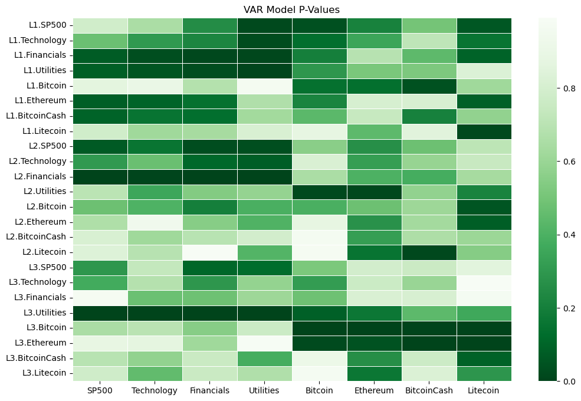

```python
# extract p-values from VAR model
var_pvalues = var_model.pvalues

# remove constant row
var_pvalues = var_pvalues.drop("const")

plt.figure(figsize = (12,8))

sns.heatmap(var_pvalues, cmap = "Greens_r", annot = False, linewidths = 0.5)

plt.title("VAR Model P-Values")
plt.show()
```

The VAR heatmap summarizes statistically significant relationships across lagged market returns. Darker regions indicate stronger evidence that previous market movements help explain future return behavior in another asset. These results reinforce earlier findings from the Granger causality analysis. Traditional equity sectors show stronger predictive relationships overall, while cryptocurrencies demonstrate tighter relationships within the digital asset market itself.